# ARIMA copy

```python
%load_ext nb_black

import time
import os
import pandas as pd
import numpy as np
import matplotlib.pyplot as plt

from pmdarima import auto_arima
import warnings

plt.style.use(style="seaborn")

%matplotlib inline
```

```
The nb_black extension is already loaded. To reload it, use:
  %reload_ext nb_black
```

### Load Data

```python
TTEC_df = pd.read_csv(
    "Resources/HistoricalData_TTEC.csv", index_col="Date", parse_dates=True
)
TTEC_df.dropna()
TTEC_df.head(100)
```

| Date | Close/Last | Volume | Open | High | Low |
| --- | --- | --- | --- | --- | --- |
| 2021-07-30 | $104.5 | 75136 | $103.24 | $104.69 | $102.41 |
| 2021-07-29 | $103.68 | 92759 | $102.01 | $104.2399 | $100.655 |
| 2021-07-28 | $101.56 | 43367 | $101.21 | $102.43 | $99.85 |
| 2021-07-27 | $100.55 | 59346 | $102.23 | $102.25 | $99.39 |
| 2021-07-26 | $102.7 | 47389 | $102.1 | $103.17 | $102.1 |
| ... | ... | ... | ... | ... | ... |
| 2021-03-16 | $92.62 | 81241 | $93.94 | $94.1774 | $92.215 |
| 2021-03-15 | $93.62 | 180730 | $92.8 | $93.71 | $91.11 |
| 2021-03-12 | $93.32 | 87675 | $92.6 | $94.56 | $91.925 |
| 2021-03-11 | $93.22 | 120942 | $91.71 | $93.51 | $90.56 |
| 2021-03-10 | $90.33 | 108658 | $88.91 | $90.75 | $88.29 |

100 rows × 5 columns

### Data cleaning and slicing, sorting by ascending date.

```python
df = TTEC_df[["Close/Last"]].copy()
df["Close/Last"] = df["Close/Last"].str.replace("$", "")
df["Close/Last"] = df["Close/Last"].astype("float")
df.sort_values("Date", ascending=True, inplace=True)
df
```

| Date | Close/Last |
| --- | --- |
| 2016-08-01 | 28.86 |
| 2016-08-02 | 28.57 |
| 2016-08-03 | 28.56 |
| 2016-08-04 | 28.90 |
| 2016-08-05 | 30.24 |
| ... | ... |
| 2021-07-26 | 102.70 |
| 2021-07-27 | 100.55 |
| 2021-07-28 | 101.56 |
| 2021-07-29 | 103.68 |
| 2021-07-30 | 104.50 |

1259 rows × 1 columns

```python
df.describe(include="all")
```

|  | Close/Last |
| --- | --- |
| count | 1259.000000 |
| mean | 45.211906 |
| std | 20.769137 |
| min | 23.790000 |
| 25% | 31.650000 |
| 50% | 39.370000 |
| 75% | 46.680000 |
| max | 111.040000 |

### Stationarity

A stationary time series is one where the properties of the series do not depend on the time of the observation. In other words, the summary statistics of the series do not depend on the time the series is observed, as is the case with series that show a trend or their mean varies over time or show seasonal effects. Here we use the adfuller() functin to determine if our series is stationary.

The Augmented Dickey-Fuller test is a type of statistical test called a unit root test. The intuition behind a unit root test is that it determines how strongly a time series is defined by a trend.

Null Hypothesis (H0): If failed to be rejected, it suggests the time series has a unit root, meaning it is non-stationary. It has some time dependent structure.

Alternate Hypothesis (H1): The null hypothesis is rejected; it suggests the time series does not have a unit root, meaning it is stationary. It does not have time-dependent structure.

We interpret this result using the p-value from the test. A p-value below a threshold (such as 5% or 1%) suggests we reject the null hypothesis (stationary), otherwise a p-value above the threshold suggests we fail to reject the null hypothesis (non-stationary).

p-value > 0.05: Fail to reject the null hypothesis (H0), the data has a unit root and is non-stationary.

p-value <= 0.05: Reject the null hypothesis (H0), the data does not have a unit root and is stationary.

```python
# Check if the series of close prices is stationary (Mean Reverting)
from statsmodels.tsa.stattools import adfuller

result = adfuller(df["Close/Last"].dropna())
print(f"ADF Statistic: {result[0]}")
print(f"p-value: {result[1]}")
```

```
ADF Statistic: 1.4332627147232284
p-value: 0.9972601324201877
```

p-value > 0.05: Fail to reject the null hypothesis (H0), the data has a unit root and is non-stationary.

### Differencing and the "i" term.

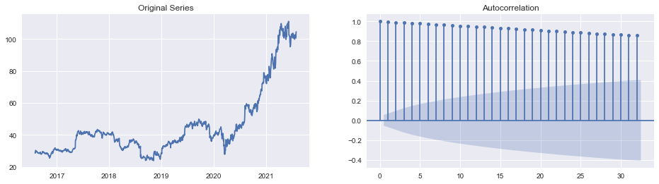

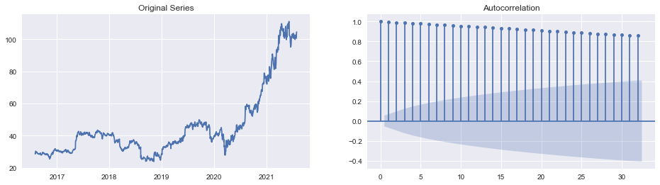

```python
from statsmodels.graphics.tsaplots import plot_acf

fig, (ax1, ax2) = plt.subplots(1, 2, figsize=(16, 4))

ax1.plot(df["Close/Last"])
ax1.set_title("Original Series")

plot_acf(df["Close/Last"], ax=ax2)
```

Note: The pair of charts is being repeated because of a bug in the plot_acf() function.

All the ACF values are close to 1, this is indicative of a non-stationary sequence. Differencing is needed to make the sequence stationary.

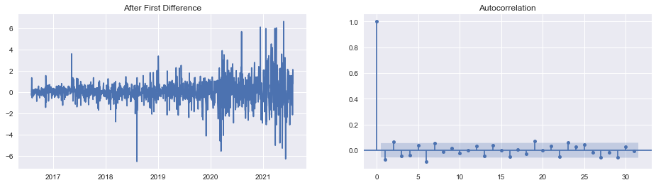

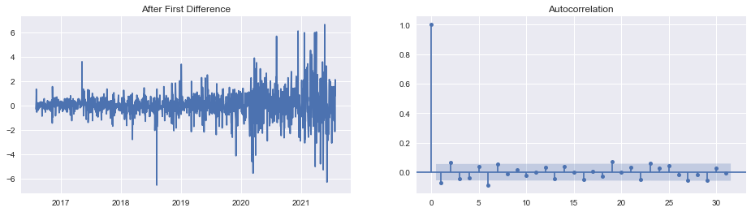

```python
diff = df["Close/Last"].diff().dropna()

fig, (ax1, ax2) = plt.subplots(1, 2, figsize=(16, 4))

ax1.plot(diff)
ax1.set_title("After First Difference")

plot_acf(diff, ax=ax2)
```

After the first differencing, one can intuitively see that the sequence's mean value is stationary.

The correct value for the "i" term in the ARIMA(p,i,q) model is 1, since that is the number of times the series had to be differentiated to achieve stationarity.

Another way to get the correct value for the number of differences needed is by use of the `pmdarima.ndiffs()` function:

```python
# pip install pmdarima

from pmdarima.arima.utils import ndiffs

ndiffs(df["Close/Last"], test="adf")
```

```
1
```

**p** and **q**

`p` is the number of lags to be used as predictors and represents the order of the Auto Regressive term of the model equation (the "p" in ARIMA(p,i,q)). The autocorrelation (plotted above) and partial autocorrelation (plotted below) functions are used for determining the "p" and "q" terms.

The **q** term is the order of the **MA** term, or moving average term (the "q" in ARIMA(p,i,q) ) .

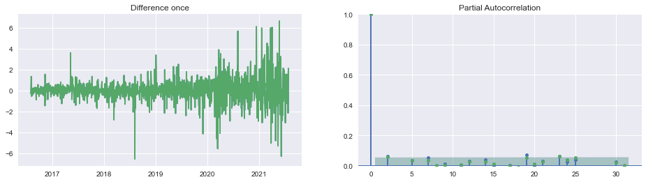

[figure not shown]

```python
from statsmodels.graphics.tsaplots import plot_pacf

diff = df["Close/Last"].diff().dropna()
fig, (x1, x2) = plt.subplots(1, 2, figsize=(16, 4))

ax1.plot(diff)
ax1.set_title("Difference once")
ax2.set_ylim(0, 1)

plot_pacf(diff, ax=ax2)
```

(The second pair of plots in the bottom row is due to a bug in the plot_pacf() function.)

A more effective method is to let the values for **p**, **i**, and **q** be computed automatically via the `auto_arima()` function:

```python
warnings.filterwarnings("ignore")
stepwise_fit = auto_arima(df["Close/Last"], trace=True, supress_warnings=True)

stepwise_fit.summary()
```

```
Performing stepwise search to minimize aic
 ARIMA(2,2,2)(0,0,0)[0]             : AIC=inf, Time=1.42 sec
 ARIMA(0,2,0)(0,0,0)[0]             : AIC=4825.502, Time=0.05 sec
 ARIMA(1,2,0)(0,0,0)[0]             : AIC=4346.589, Time=0.10 sec
 ARIMA(0,2,1)(0,0,0)[0]             : AIC=inf, Time=0.28 sec
 ARIMA(2,2,0)(0,0,0)[0]             : AIC=4232.580, Time=0.11 sec
 ARIMA(3,2,0)(0,0,0)[0]             : AIC=4170.856, Time=0.20 sec
 ARIMA(4,2,0)(0,0,0)[0]             : AIC=4093.066, Time=0.19 sec
 ARIMA(5,2,0)(0,0,0)[0]             : AIC=4081.816, Time=0.26 sec
 ARIMA(5,2,1)(0,0,0)[0]             : AIC=inf, Time=1.04 sec
 ARIMA(4,2,1)(0,0,0)[0]             : AIC=inf, Time=1.68 sec
 ARIMA(5,2,0)(0,0,0)[0] intercept   : AIC=4083.813, Time=0.57 sec

Best model:  ARIMA(5,2,0)(0,0,0)[0]
Total fit time: 5.915 seconds
```

SARIMAX Results

| Dep. Variable: | y | No. Observations: | 1259 |
| --- | --- | --- | --- |
| Model: | SARIMAX(5, 2, 0) | Log Likelihood | -2034.908 |
| Date: | Sun, 01 Aug 2021 | AIC | 4081.816 |
| Time: | 20:46:57 | BIC | 4112.635 |
| Sample: | 0 | HQIC | 4093.399 |
|  | - 1259 |  |  |
| Covariance Type: | opg |  |  |

|  | coef | std err | z | P>\|z\| | [0.025 | 0.975] |
| --- | --- | --- | --- | --- | --- | --- |
| ar.L1 | -0.8779 | 0.017 | -50.210 | 0.000 | -0.912 | -0.844 |
| ar.L2 | -0.6170 | 0.024 | -26.198 | 0.000 | -0.663 | -0.571 |
| ar.L3 | -0.4798 | 0.026 | -18.170 | 0.000 | -0.532 | -0.428 |
| ar.L4 | -0.3361 | 0.025 | -13.631 | 0.000 | -0.384 | -0.288 |
| ar.L5 | -0.1026 | 0.018 | -5.566 | 0.000 | -0.139 | -0.066 |
| sigma2 | 1.4904 | 0.031 | 48.843 | 0.000 | 1.431 | 1.550 |

| Ljung-Box (L1) (Q): | 0.54 | Jarque-Bera (JB): | 1817.21 |
| --- | --- | --- | --- |
| Prob(Q): | 0.46 | Prob(JB): | 0.00 |
| Heteroskedasticity (H): | 10.37 | Skew: | -0.24 |
| Prob(H) (two-sided): | 0.00 | Kurtosis: | 8.87 |

Warnings:  
[1] Covariance matrix calculated using the outer product of gradients (complex-step).

We now fit the ARIMA model:

```python
warnings.filterwarnings("ignore")

from statsmodels.tsa.arima_model import ARIMA

model = ARIMA(df["Close/Last"], order=(1, 1, 0))
result = model.fit(disp=0)
print(result.summary())
```

```
                             ARIMA Model Results
==============================================================================
Dep. Variable:           D.Close/Last   No. Observations:                 1258
Model:                 ARIMA(1, 1, 0)   Log Likelihood               -1930.813
Method:                       css-mle   S.D. of innovations              1.123
Date:                Sun, 01 Aug 2021   AIC                           3867.626
Time:                        20:46:57   BIC                           3883.038
Sample:                             1   HQIC                          3873.418

======================================================================================
                         coef    std err          z      P>|z|      [0.025      0.975]
--------------------------------------------------------------------------------------
const                  0.0601      0.030      2.034      0.042       0.002       0.118
ar.L1.D.Close/Last    -0.0712      0.028     -2.533      0.011      -0.126      -0.016
                                    Roots
=============================================================================
                  Real          Imaginary           Modulus         Frequency
-----------------------------------------------------------------------------
AR.1          -14.0389           +0.0000j           14.0389            0.5000
-----------------------------------------------------------------------------
```

### Residuals

The “residuals” in a time series model are what is left over after fitting a model. For many (but not all) time series models, the residuals are equal to the difference between the observations and the corresponding fitted values.

Residuals are useful in checking whether a model has adequately captured the information in the data. A good forecasting method will yield residuals with the following properties:

- The residuals are uncorrelated. If there are correlations between residuals, then there is information left in the residuals which should be used in computing forecasts.
- The residuals have zero mean. If the residuals have a mean other than zero, then the forecasts are biased.

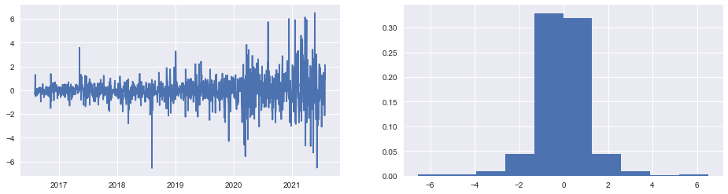

```python
# Residuals

residuals = pd.DataFrame(result.resid)

fig, (ax1, ax2) = plt.subplots(1, 2, figsize=(16, 4))

ax1.plot(residuals)
ax2.hist(residuals, density=True)
```

Here we see the residuals' mean is around 0.

We not plot the first 60 days of the stock prices and the predicted values. We can see the predicted values pretty much follow the actual values, which is a good indication that our model is a good fit. But in this case the model is making predictions using the same training data.

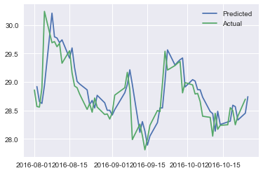

```python
fig, ax = plt.subplots()
ax.plot(
    result.predict(start=1, end=60, dynamic=False, typ="levels"),
    label="Predicted",
)
ax.plot(df["Close/Last"].head(60), label="Actual")
leg = ax.legend()
```

### Test sets and predictions

Here we split the dataset into training and testing sets. Training set goes from the first date in the original dataset until the record at the 80% mark. Test set goes from 80% to the rest of the records. For example, if there are 1258 records, the training set will include the first 1006, while the test set will include the remaining 252.

```python
howmany = int(len(df) * 0.8)
tr_set = df["Close/Last"][:howmany]
ts_set = df["Close/Last"][howmany:]
print(len(ts_set))
print(len(tr_set))
print(len(df))
ts_set
```

```
252
1007
1259
```

```
Date
2020-07-31     47.46
2020-08-03     48.60
2020-08-04     50.96
2020-08-05     52.46
2020-08-06     58.15
               ...
2021-07-26    102.70
2021-07-27    100.55
2021-07-28    101.56
2021-07-29    103.68
2021-07-30    104.50
Name: Close/Last, Length: 252, dtype: float64
```

```python
tr_set
```

```
Date
2016-08-01    28.86
2016-08-02    28.57
2016-08-03    28.56
2016-08-04    28.90
2016-08-05    30.24
              ...
2020-07-24    45.97
2020-07-27    47.79
2020-07-28    47.02
2020-07-29    47.88
2020-07-30    47.75
Name: Close/Last, Length: 1007, dtype: float64
```

We now fit the model to our training set.

```python
model = ARIMA(tr_set, order=(1, 1, 0))
result = model.fit(disp=0)
print(result.summary())
```

```
                             ARIMA Model Results
==============================================================================
Dep. Variable:           D.Close/Last   No. Observations:                 1006
Model:                 ARIMA(1, 1, 0)   Log Likelihood               -1250.630
Method:                       css-mle   S.D. of innovations              0.839
Date:                Sun, 01 Aug 2021   AIC                           2507.260
Time:                        20:46:58   BIC                           2522.001
Sample:                             1   HQIC                          2512.861

======================================================================================
                         coef    std err          z      P>|z|      [0.025      0.975]
--------------------------------------------------------------------------------------
const                  0.0188      0.023      0.821      0.412      -0.026       0.064
ar.L1.D.Close/Last    -0.1527      0.031     -4.904      0.000      -0.214      -0.092
                                    Roots
=============================================================================
                  Real          Imaginary           Modulus         Frequency
-----------------------------------------------------------------------------
AR.1           -6.5479           +0.0000j            6.5479            0.5000
-----------------------------------------------------------------------------
```

And here we forecast the next 30 days of closing prices, starting with the first date of the test set.

```python
step = 30

fc, se, conf = result.forecast(step)

print(fc)  # 30 day forecasts
print(se)  # Standard errors
print(conf)  # Confidence levels
```

```
[47.79156837 47.8069345  47.82630228 47.84505893 47.86390891 47.88274463
 47.90158253 47.9204201  47.93925772 47.95809533 47.97693294 47.99577056
 48.01460817 48.03344578 48.0522834  48.07112101 48.08995862 48.10879623
 48.12763385 48.14647146 48.16530907 48.18414669 48.2029843  48.22182191
 48.24065952 48.25949714 48.27833475 48.29717236 48.31600998 48.33484759]
[0.83880311 1.09940189 1.31983699 1.50695052 1.67346766 1.82482513
 1.96455973 2.09499422 2.21777073 2.33409793 2.44489658 2.55088719
 2.65264615 2.75064316 2.84526693 2.93684356 3.02564972 3.11192262
 3.19586742 3.277663   3.35746644 3.43541657 3.51163682 3.58623749
 3.65931763 3.73096658 3.80126529 3.87028732 3.93809981 4.0047642 ]
[[46.14754447 49.43559226]
 [45.65214639 49.9617226 ]
 [45.23946932 50.41313524]
 [44.89149018 50.79862768]
 [44.58397256 51.14384525]
 [44.30615311 51.45933615]
 [44.05111621 51.75204885]
 [43.81430688 52.02653332]
 [43.59250697 52.28600847]
 [43.38334745 52.53284321]
 [43.1850237  52.76884219]
 [42.99612354 52.99541758]
 [42.81551725 53.21369909]
 [42.64228426 53.4246073 ]
 [42.47566268 53.62890411]
 [42.31501341 53.82722861]
 [42.15979414 54.02012311]
 [42.00953997 54.20805249]
 [41.86384881 54.39141889]
 [41.72237004 54.57057288]
 [41.58479578 54.74582237]
 [41.45085393 54.91743944]
 [41.3203026  55.085666  ]
 [41.19292559 55.25071823]
 [41.06852877 55.41279028]
 [40.94693701 55.57205727]
 [40.82799169 55.72867781]
 [40.7115486  55.88279613]
 [40.59747618 56.03454377]
 [40.485654   56.18404118]]
```

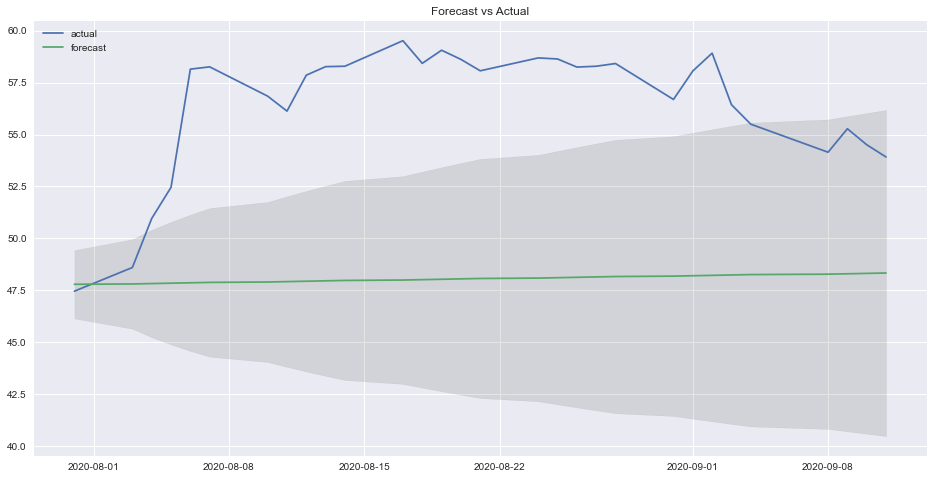

```python
fc = pd.Series(fc, index=ts_set[:step].index)

lower = pd.Series(conf[:, 0], index=ts_set[:step].index)
upper = pd.Series(conf[:, 1], index=ts_set[:step].index)

plt.figure(figsize=(16, 8))
plt.plot(ts_set[:step], label="actual")
plt.plot(fc, label="forecast")
plt.fill_between(lower.index, lower, upper, color="k", alpha=0.1)
plt.title("Forecast vs Actual")
plt.legend(loc="upper left")
```